# How to run standard statistics

In the first exercise, you practiced plotting ERPs and many data manipulation commands.

Now we’ll move on to running some straightforward statistics and how to plot those alongside the ERPs.

Remember, help for any command can be looked up using ?command in console, or searching for it in the help pane.

## Packages and commands

You’ll need to load the following packages * tidyverse * afex * broom

We’ll be using the following new commands * group_by() * summarise() * mutate() * t.test() * aov_ez() * filter() * map()/map_dbl() * lsmeans()

First, load the packages named above, and reload the data frame you saved from the first exercise using *load()* or *read_csv()*.

```r
library(tidyverse)
library(afex)
library(broom)
load('../user_data/final_df.RData')
theme_set(theme_classic())
```

## Pre-specified time windows

Choose a time-range to analyse:

e.g. P1 ~85ms - 135ms

Let’s start by examining ERPs in the P1 time window. We’ll begin by pretending this isn’t a 2 X 3 design, and doing paired t-tests on mean amplitudes in the time window from approximately 85-135 ms.

Rows from a dataframe can be selected using *filter()*. Filter accepts logical, conditional arguments. For example, filter(Subject == 5) would select only rows from subject 5.

Use filter to select rows where Time >= 85 and Time <= 135. Note that with multiple conditions, you have to specify the full argument (e.g. x > 5 & x < 8; not x > 5 & <8)

*group_by()* is used to group rows together according to the values or levels of the specified column.

*summarise()* is used to create summaries of multiple values.

Assign this to a separate data frame, as we want to keep the original for later analyses.

```r
obj_pairs <- final_df %>%
  filter(Time >= 85 & Time <= 135) %>%
  group_by(Subject, Object) %>%
  summarise(amplitude = mean(amplitude))

head(obj_pairs)
```

```
## # A tibble: 6 x 3
## # Groups:   Subject [3]
##   Subject     Object amplitude
##     <int>      <chr>     <dbl>
## 1       1 Non-Object 4.4451977
## 2       1     Object 4.8054385
## 3       2 Non-Object 0.4865543
## 4       2     Object 1.3679577
## 5       3 Non-Object 2.8637337
## 6       3     Object 4.0010472
```

Before running statistics, let’s do some plots.

Set up a *ggplot()* object for your new dataframe.

e.g.

```
ggplot(new_df, aes(x = Object, y = amplitude))
```

For the purposes of demonstration, let’s start with a bar plot.

Note: part of the purpose of this demonstration is to show that bar plots are *bad* ;)

We’ll also add 95% confidence intervals.

Add bars using *stat_summary(geom = “bar”)*.

Add errorbars using geom = “pointrange”; remember to change fun.data to plot confidence intervals!

```
## No summary function supplied, defaulting to `mean_se()
```

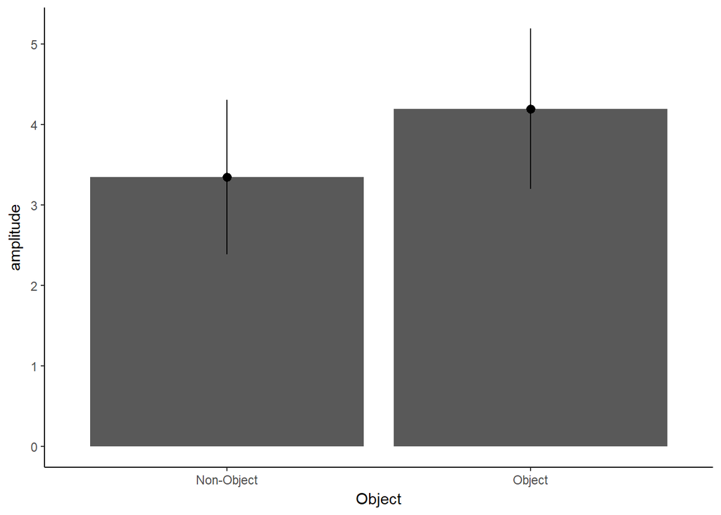

```r
ggplot(obj_pairs, aes(x = Object, y = amplitude)) +
  stat_summary(geom = "bar") +
  stat_summary(fun.data = mean_cl_normal, geom = "pointrange")
```

We can do much better than this. Add individual data points using *geom_point()*. Remember: each layer of the plot is drawn consecutively.

```
## No summary function supplied, defaulting to `mean_se()
```

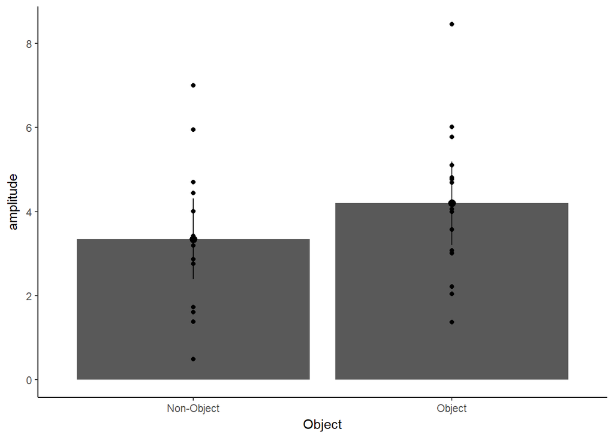

```r
ggplot(obj_pairs, aes(x = Object, y = amplitude)) +
  stat_summary(geom = "bar") +
  geom_point() +
  stat_summary(fun.data = mean_cl_normal, geom = "pointrange")
```

Let’s ditch the bars entirely and add lines connecting the datapoints from within each subject, so that we can see the trend for each subject.

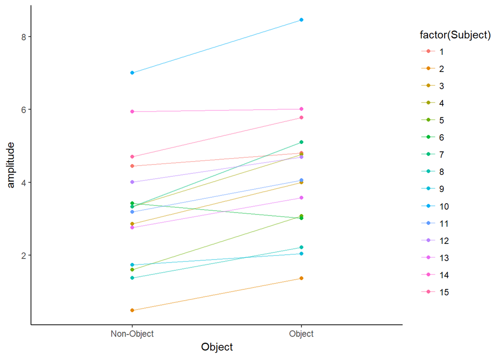

```r
ggplot(obj_pairs, aes(x = Object, y = amplitude, colour = factor(Subject))) +
  geom_point() +
  geom_line(aes(group = Subject), alpha = 0.5)
```

This looks like Object amplitudes are overall higher, although the distributions substantially overlap. The direction is mostly consistent across subjects, with only one person going in the opposite direction.

### T-tests

Let’s go ahead with our paired t-test using the *t.test()* command.

*t.test()* can be used with typical R modelling syntax:

```
dv ~ iv
```

In R, ~ used in a formula usually means “modelled by”. In this case we want to model amplitude by Object. Make sure you `paired = TRUE` to indicate that this is a **paired**, dependent t-test. Allocate the result to a variable using *<-*

```r
test_result <- t.test(amplitude~Object, data = obj_pairs, paired = TRUE)
test_result
```

```
##
##  Paired t-test
##
## data:  amplitude by Object
## t = -5.6145, df = 14, p-value = 6.38e-05
## alternative hypothesis: true difference in means is not equal to 0
## 95 percent confidence interval:
##  -1.1751415 -0.5254875
## sample estimates:
## mean of the differences
##              -0.8503145
```

The resulting variable is a list object with individual elements that can be accessed using the $ operator or [] subsetting.

For example, if you stored the output of t-test in a variable called test_result, you could get the p-value as follows:

```
test_result$p.value
test_result[3]
```

You query the structure of an R object using *str()* - try now.

```r
str(test_result)
```

```
## List of 9
##  $ statistic  : Named num -5.61
##   ..- attr(*, "names")= chr "t"
##  $ parameter  : Named num 14
##   ..- attr(*, "names")= chr "df"
##  $ p.value    : num 6.38e-05
##  $ conf.int   : atomic [1:2] -1.175 -0.525
##   ..- attr(*, "conf.level")= num 0.95
##  $ estimate   : Named num -0.85
##   ..- attr(*, "names")= chr "mean of the differences"
##  $ null.value : Named num 0
##   ..- attr(*, "names")= chr "difference in means"
##  $ alternative: chr "two.sided"
##  $ method     : chr "Paired t-test"
##  $ data.name  : chr "amplitude by Object"
##  - attr(*, "class")= chr "htest"
```

Helpfully, the output of many stats objects can be tidied up and turned into a dataframe using *tidy()* from the *broom* package, which makes them easier to use for subsequent plotting (see next section). Try that now (no need to assign the output to a new variable).

```r
tidy(test_result)
```

```
##     estimate statistic     p.value parameter  conf.low  conf.high
## 1 -0.8503145 -5.614507 6.38018e-05        14 -1.175142 -0.5254875
##          method alternative
## 1 Paired t-test   two.sided
```

### ANOVA

Of course, the actual design is a 2 X 3 repeated measures ANOVA.

There are several ways to run ANOVA in R. We’ll use *aov_ez()* from the **afex** package.

*aov_ez()* simplifies the method of specifying repeated/mixed ANOVAs over base R’s *aov()* commands.

```r
aov_style <- final_df %>%
  filter(Time >= 85 & Time <= 135) %>%
  group_by(Subject,Object, Frequency) %>%
  summarise(amplitude = mean(amplitude))

aov_out <- aov_ez(id = "Subject", dv = "amplitude", data = aov_style, within = c("Object", "Frequency"))
aov_out
```

```
## Anova Table (Type 3 tests)
##
## Response: amplitude
##             Effect          df  MSE         F  ges p.value
## 1           Object       1, 14 0.52 31.52 ***  .05  <.0001
## 2        Frequency 1.77, 24.83 1.00 12.55 ***  .07   .0003
## 3 Object:Frequency 2.00, 27.97 0.60      2.30 .009     .12
## ---
## Signif. codes:  0 '***' 0.001 '**' 0.01 '*' 0.05 '+' 0.1 ' ' 1
##
## Sphericity correction method: GG
```

### Post-hoc tests

Simple post-hoc tests can be done with *lsmeans()* *and contrast()* from the **lsmeans** package.

```r
post_hocs <- lsmeans(aov_out, c("Object","Frequency"), contr = "pairwise", adjust = "holm")
post_hocs
```

```
## $lsmeans
##  Object     Frequency   lsmean        SE    df lower.CL upper.CL
##  Non.Object BB        4.084713 0.4909919 19.75 3.059689 5.109737
##  Object     BB        4.761815 0.4909919 19.75 3.736791 5.786839
##  Non.Object HSF       3.008859 0.4909919 19.75 1.983834 4.033883
##  Object     HSF       4.348576 0.4909919 19.75 3.323552 5.373600
##  Non.Object LSF       2.948121 0.4909919 19.75 1.923097 3.973145
##  Object     LSF       3.482245 0.4909919 19.75 2.457221 4.507269
##
## Confidence level used: 0.95
##
## $contrasts
##  contrast                           estimate        SE    df t.ratio
##  Non.Object,BB - Object,BB       -0.67710233 0.2767516 41.78  -2.447
##  Non.Object,BB - Non.Object,HSF   1.07585457 0.3153682 54.03   3.411
##  Non.Object,BB - Object,HSF      -0.26386303 0.3091388 53.97  -0.854
##  Non.Object,BB - Non.Object,LSF   1.13659163 0.3153682 54.03   3.604
##  Non.Object,BB - Object,LSF       0.60246796 0.3091388 53.97   1.949
##  Object,BB - Non.Object,HSF       1.75295690 0.3091388 53.97   5.670
##  Object,BB - Object,HSF           0.41323930 0.3153682 54.03   1.310
##  Object,BB - Non.Object,LSF       1.81369396 0.3091388 53.97   5.867
##  Object,BB - Object,LSF           1.27957029 0.3153682 54.03   4.057
##  Non.Object,HSF - Object,HSF     -1.33971761 0.2767516 41.78  -4.841
##  Non.Object,HSF - Non.Object,LSF  0.06073706 0.3153682 54.03   0.193
##  Non.Object,HSF - Object,LSF     -0.47338662 0.3091388 53.97  -1.531
##  Object,HSF - Non.Object,LSF      1.40045467 0.3091388 53.97   4.530
##  Object,HSF - Object,LSF          0.86633099 0.3153682 54.03   2.747
##  Non.Object,LSF - Object,LSF     -0.53412368 0.2767516 41.78  -1.930
##  p.value
##   0.1310
##   0.0111
##   0.7943
##   0.0068
##   0.3391
##   <.0001
##   0.5869
##   <.0001
##   0.0018
##   0.0002
##   0.8480
##   0.5261
##   0.0004
##   0.0652
##   0.3391
##
## P value adjustment: holm method for 15 tests
```